# Chapter 4 - Classification

Rafael S Toledo

November 4, 2016

## **Applied Exercises**

**Q10. This question should be answered using the `Weekly` data set, which is part of the `ISLR` package. This data is similar in nature to the `Smarket` data from this chapter’s lab, except that is contains 1,089 weekly returns for 21 years, from the beginning of the 1990 to the end of the 2010.**

**(a) Produce some numerical and graphical summaries of the `Weekly` data. Do there appear to be any patterns?**

```r
require(ISLR)
data(Weekly)
summary(Weekly)
```

```
##       Year           Lag1               Lag2               Lag3
##  Min.   :1990   Min.   :-18.1950   Min.   :-18.1950   Min.   :-18.1950
##  1st Qu.:1995   1st Qu.: -1.1540   1st Qu.: -1.1540   1st Qu.: -1.1580
##  Median :2000   Median :  0.2410   Median :  0.2410   Median :  0.2410
##  Mean   :2000   Mean   :  0.1506   Mean   :  0.1511   Mean   :  0.1472
##  3rd Qu.:2005   3rd Qu.:  1.4050   3rd Qu.:  1.4090   3rd Qu.:  1.4090
##  Max.   :2010   Max.   : 12.0260   Max.   : 12.0260   Max.   : 12.0260
##       Lag4               Lag5              Volume
##  Min.   :-18.1950   Min.   :-18.1950   Min.   :0.08747
##  1st Qu.: -1.1580   1st Qu.: -1.1660   1st Qu.:0.33202
##  Median :  0.2380   Median :  0.2340   Median :1.00268
##  Mean   :  0.1458   Mean   :  0.1399   Mean   :1.57462
##  3rd Qu.:  1.4090   3rd Qu.:  1.4050   3rd Qu.:2.05373
##  Max.   : 12.0260   Max.   : 12.0260   Max.   :9.32821
##      Today          Direction
##  Min.   :-18.1950   Down:484
##  1st Qu.: -1.1540   Up  :605
##  Median :  0.2410
##  Mean   :  0.1499
##  3rd Qu.:  1.4050
##  Max.   : 12.0260
```

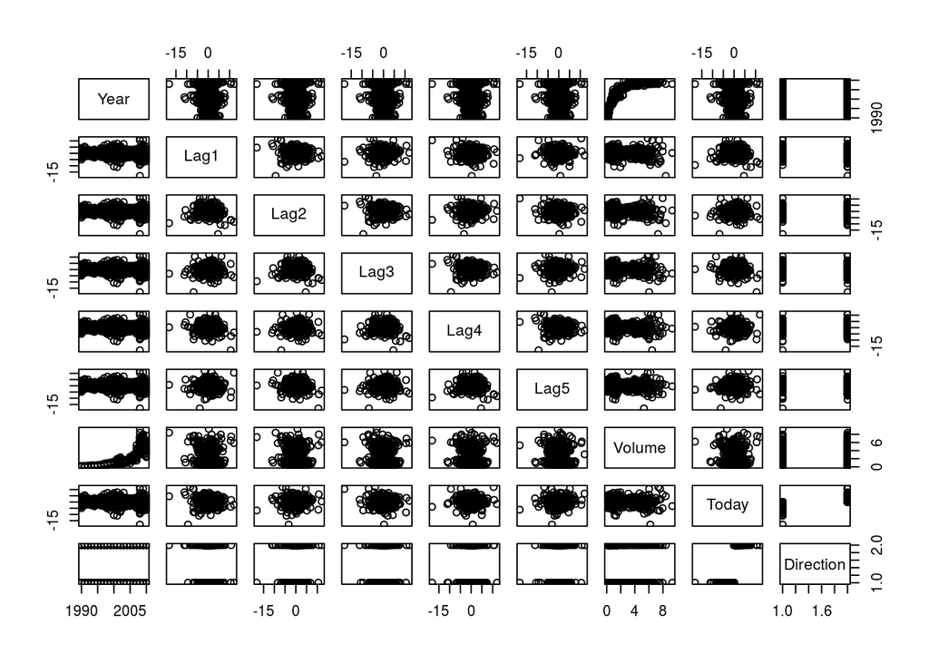

```r
pairs(Weekly)
```

Seemingly, the only evidence is at $Volume \times Year$, where shows a logarithmic pattern.

**(b) Use the full data set to perform a logistic regression with `Direction` as the response and the five lag variables plus `Volume` as predictors. Use the summary function to print the results. Do any of the predictors appear to be statistically significant? If so, which ones?**

```r
glm.fit <- glm(Direction ~ Lag1 + Lag2 + Lag3 + Lag4 + Lag5 + Volume, data=Weekly, family="binomial")
summary(glm.fit)
```

```
##
## Call:
## glm(formula = Direction ~ Lag1 + Lag2 + Lag3 + Lag4 + Lag5 +
##     Volume, family = "binomial", data = Weekly)
##
## Deviance Residuals:
##     Min       1Q   Median       3Q      Max
## -1.6949  -1.2565   0.9913   1.0849   1.4579
##
## Coefficients:
##             Estimate Std. Error z value Pr(>|z|)
## (Intercept)  0.26686    0.08593   3.106   0.0019 **
## Lag1        -0.04127    0.02641  -1.563   0.1181
## Lag2         0.05844    0.02686   2.175   0.0296 *
## Lag3        -0.01606    0.02666  -0.602   0.5469
## Lag4        -0.02779    0.02646  -1.050   0.2937
## Lag5        -0.01447    0.02638  -0.549   0.5833
## Volume      -0.02274    0.03690  -0.616   0.5377
## ---
## Signif. codes:  0 '***' 0.001 '**' 0.01 '*' 0.05 '.' 0.1 ' ' 1
##
## (Dispersion parameter for binomial family taken to be 1)
##
##     Null deviance: 1496.2  on 1088  degrees of freedom
## Residual deviance: 1486.4  on 1082  degrees of freedom
## AIC: 1500.4
##
## Number of Fisher Scoring iterations: 4
```

Lag2.

**(c) Compute the confusion matrix and overall fraction of correct predictions. Explain what the confusion matrix is telling you about the types of mistakes made by logistic regression.**

```r
glm.probs <- predict(glm.fit, type="response")
glm.preds <- ifelse(glm.probs>.5, "Up", "Down")
cm <- table(Weekly$Direction, glm.preds)
cm
```

```
##       glm.preds
##        Down  Up
##   Down   54 430
##   Up     48 557
```

There are a predominance of *Up* prediction. The model predicts well the *Up* direction, but it predict poorly the *Down* direction.

```r
# Here i consider the Null/(-) as `Down` and the Non-null/(+) as `Up`
FP_rate <- cm["Down", "Up"]/(cm["Down", "Up"] + cm["Down", "Down"])
TP_rate <- cm["Up", "Up"]/(cm["Up", "Up"] + cm["Up", "Down"])
precision <- cm["Up", "Up"]/(cm["Up", "Up"] + cm["Down", "Up"])

data.frame("measurements"=c("specificity", "sensibility", "precision"), "rate"=c(FP_rate, TP_rate, precision))
```

```
##   measurements      rate
## 1  specificity 0.8884298
## 2  sensibility 0.9206612
## 3    precision 0.5643364
```

**(d) Now fit the logistic regression model using a training data period from 1990 to 2008, with `Lag2` as the only predictor. Compute the confusion matrix and the overall fraction of correct predictions for the held out data (that is, the data from 2009 and 2010).**

```r
trainset = (Weekly$Year<=2008)
testset = Weekly[!trainset,]

glm.fit.d <- glm(Direction ~ Lag2, data=Weekly, subset=trainset, family="binomial")
glm.probs.d <- predict(glm.fit.d, type="response", newdata=testset)
glm.preds.d <- ifelse(glm.probs.d>.5, "Up", "Down")
cm.d <- table(testset$Direction, glm.preds.d)
cm.d
```

```
##       glm.preds.d
##        Down Up
##   Down    9 34
##   Up      5 56
```

```r
# compute overall of correct predictions
acc.d <- (cm.d["Down", "Down"] + cm.d["Up", "Up"])/sum(cm.d)
acc.d
```

```
## [1] 0.625
```

**(e) Repeat (d) using LDA.**

```r
library(MASS)
lda.fit.e <- lda(Direction ~ Lag2, data=Weekly, subset=trainset)
lda.preds.e <- predict(lda.fit.e, newdata=testset)
cm.e <- table(testset$Direction, lda.preds.e$class)
cm.e
```

```
##
##        Down Up
##   Down    9 34
##   Up      5 56
```

```r
# compute overall of correct predictions
acc.e<- (cm.e["Down", "Down"] + cm.e["Up", "Up"])/sum(cm.e)
acc.e
```

```
## [1] 0.625
```

**(f) Repeat (d) using QDA.**

```r
qda.fit.f <- qda(Direction ~ Lag2, data=Weekly, subset=trainset)
qda.preds.f <- predict(qda.fit.f, newdata=testset)
cm.f <- table(testset$Direction, qda.preds.f$class)
cm.f
```

```
##
##        Down Up
##   Down    0 43
##   Up      0 61
```

```r
# compute overall of correct predictions
acc.f<- (cm.f["Down", "Down"] + cm.f["Up", "Up"])/sum(cm.f)
acc.f
```

```
## [1] 0.5865385
```

**(g) Repeat (d) using KNN with $K$ =1.**

```r
library(class)
set.seed(1)

train.g = Weekly[trainset, c("Lag2", "Direction")]
knn.pred = knn(train=data.frame(train.g$Lag2), test=data.frame(testset$Lag2), cl=train.g$Direction, k=1)
cm.g <- table(testset$Direction, knn.pred)
cm.g
```

```
##       knn.pred
##        Down Up
##   Down   21 22
##   Up     30 31
```

```r
# compute overall of correct predictions
acc.g <- (cm.g["Down", "Down"] + cm.g["Up", "Up"])/sum(cm.g)
acc.g
```

```
## [1] 0.5
```

**(h) Which of these methods appears to provide the best results on this data?**

```r
rbind(acc.d, acc.e, acc.f, acc.g)
```

```
##            [,1]
## acc.d 0.6250000
## acc.e 0.6250000
## acc.f 0.5865385
## acc.g 0.5000000
```

The models from letter *d* and *e*, respectively `Logistic Regression` and `LDA`.

**(i) Experiment with different combinations of predictors, including possible transformations and interactions, for each of the methods. Report the variables, method, and associated confusion matrix that appears to provide the best results on the held out data. Note that you should also experiment with values for $K$ in the KNN classifier.**

I try many values of K.

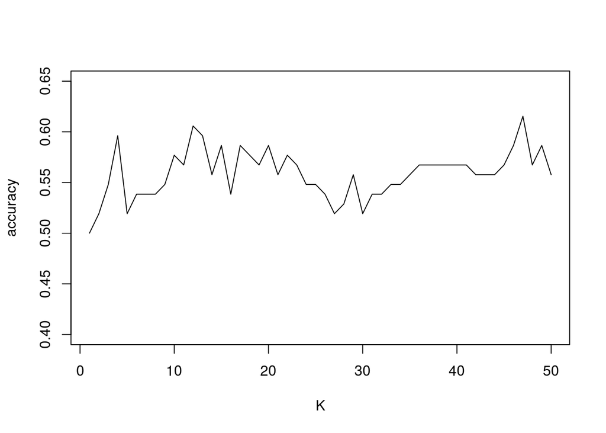

```r
set.seed(1)

results <- data.frame(k=1:50, acc=NA)
for(i in 1:50){
  knn.pred = knn(train=data.frame(train.g$Lag2), test=data.frame(testset$Lag2), cl=train.g$Direction, k=i)
  cm <- table(testset$Direction, knn.pred)
  acc <- (cm["Down", "Down"] + cm["Up", "Up"])/sum(cm)
  results$acc[i] <- acc
}

plot(x=results$k, y=results$acc, type="l", xlab="K", ylab="accuracy", ylim=c(.4,.65))
```

Now, using a QDA model with all Lags predictors plus Volume.

```r
qda.fit <- qda(Direction ~ Lag1+Lag2+Lag3+Lag4+Lag5+Volume, data=Weekly, subset=trainset)
qda.preds <- predict(qda.fit, testset)
# show accuracy
print( sum(qda.preds$class==testset$Direction)/length(qda.preds$class))
```

```
## [1] 0.4326923
```

It had a worse performance than using only the `Lag2` predictor shown in *g*.

Again on QDA model, i try with interactive variables between all Lags predictors.

```r
qda.fit <- qda(Direction ~ Lag1*Lag2*Lag3*Lag4*Lag5 + Volume, data=Weekly, subset=trainset)
qda.preds <- predict(qda.fit, testset)
# show accuracy
print( sum(qda.preds$class==testset$Direction)/length(qda.preds$class))
```

```
## [1] 0.4134615
```

The accuracy was even worse than before.

For last, i try the same predictors schema using LDA.

```r
lda.fit <- lda(Direction ~ Lag1*Lag2*Lag3*Lag4*Lag5 + Volume, data=Weekly, subset=trainset)
lda.preds <- predict(lda.fit, testset)
# show accuracy
print( sum(lda.preds$class==testset$Direction)/length(lda.preds$class))
```

```
## [1] 0.4423077
```

The LDA performance kept similar of the QDA.

**Q11. In this problem, you will develop a model to predict whether a given car gets high or low gas mileage based on the `Auto` data set.**

```r
remove(list=ls())
data(Auto)
```

**(a) Create a binary variable, `mpg01`, that contains a 1 if `mpg` contains a value above its median, and a 0 if `mpg` contains a value below its median. You can compute the median using the `median()` function. Note you may find it helpful to use the `data.frame()` function to create a single data set containing both `mpg01` and the other `Auto` variables.**

```r
Auto$mpg01 <- with(ifelse(mpg>median(mpg), "1", "0"), data=Auto)
```

**(b) Explore the data graphically in order to investigate the association between `mpg01` and the other features. Which of the other features seem most likely to be useful in predicting `mpg01`? Scatterplots and boxplots may be useful tools to answer this question. Describe your findings.**

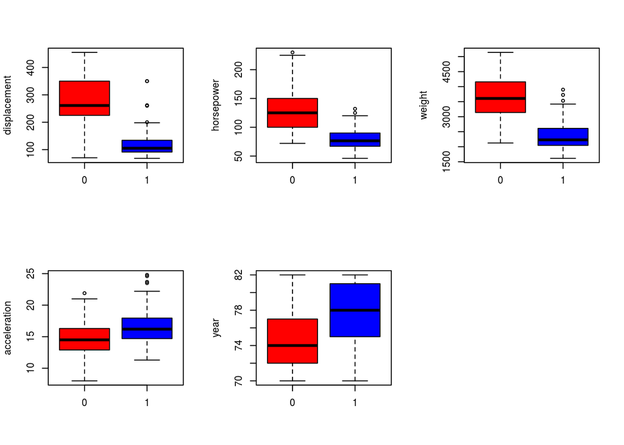

```r
attach(Auto)

# Boxplots
par(mfrow=c(2,3))
for(i in names(Auto)){
  # excluding the own mpgs variables and others categorical variables
  if( grepl(i, pattern="^mpg|cylinders|origin|name")){ next}
  boxplot(eval(parse(text=i)) ~ mpg01, ylab=i, col=c("red", "blue"))
}
```

As shown in the boxplot, all variables present some trend with `mpg01`.

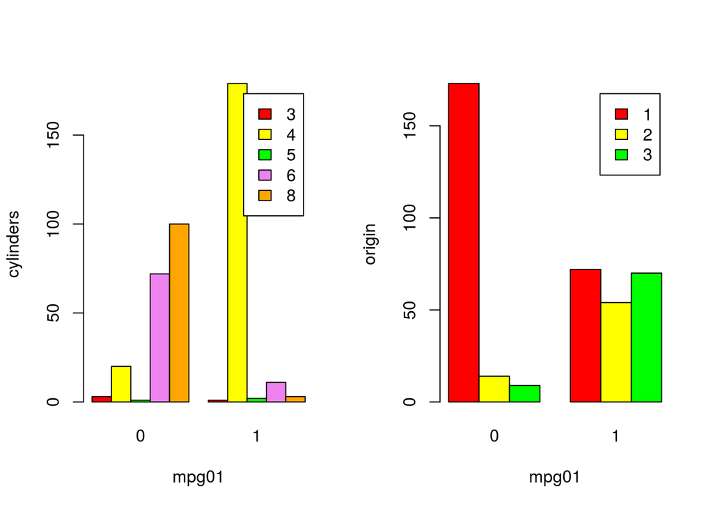

```r
# for the categorical variables i do barplots
colors = c("red", "yellow", "green", "violet", "orange", "blue", "pink", "cyan")
par(mfrow=c(1,2))
for(i in c("cylinders", "origin")){
  aux <- table(eval(parse(text=i)), mpg01)
  cols <- colors[1:nrow(aux)]
  barplot(aux, xlab="mpg01", ylab=i, beside=T,  legend=rownames(aux), col=cols)
}
```

At the barplots, `cylinders` and `origin` also show relation with `mpg01`. For instance, on dataset cars of lower mpg are majoraty from origin `1`, which is American.

**(c) Split the data into a training set and a test set.**

```r
# splitting the train and test set into 75% and 25%
set.seed(1)
rows <- sample(x=nrow(Auto), size=.75*nrow(Auto))
trainset <- Auto[rows, ]
testset <- Auto[-rows, ]
```

**(d) Perform LDA on the training data in order to predict `mpg01` using the variables that seemed most associated with `mpg01` in (b). What is the test error of the model obtained?**

I use all variables, but `name`, since all appears correlation with `mpg01`.

```r
library(MASS)
lda.fit <- lda(mpg01 ~ displacement+horsepower+weight+acceleration+year+cylinders+origin, data=trainset)
lda.pred <- predict(lda.fit, testset)
table(testset$mpg01, lda.pred$class)
```

```
##
##      0  1
##   0 43  7
##   1  4 44
```

```r
# test-error
round(sum(lda.pred$class!=testset$mpg01)/nrow(testset)*100,2)
```

```
## [1] 11.22
```

**(e) Perform QDA on the training data in order to predict `mpg01` using the variables that seemed most associated with `mpg01` in (b). What is the test error of the model obtained?**

```r
qda.fit <- qda(mpg01 ~ displacement+horsepower+weight+acceleration+year+cylinders+origin, data=trainset)
qda.pred <- predict(qda.fit, testset)
table(testset$mpg01, qda.pred$class)
```

```
##
##      0  1
##   0 44  6
##   1  4 44
```

```r
# test-error
round(sum(qda.pred$class!=testset$mpg01)/nrow(testset)*100,2)
```

```
## [1] 10.2
```

**(f) Perform logistic regression on the training data in order to predict `mpg01` using the variables that seemed most associated with `mpg01` in (b). What is the test error of the model obtained?**

```r
lr.fit <- glm(as.factor(mpg01) ~ displacement+horsepower+weight+acceleration+year+cylinders+origin, data=trainset, family="binomial")
lr.probs <- predict(lr.fit, testset, type="response")
lr.pred <- ifelse(lr.probs>0.5, "1", "0")
table(testset$mpg01, lr.pred)
```

```
##    lr.pred
##      0  1
##   0 43  7
##   1  6 42
```

```r
# test-error
round(sum(lr.pred!=testset$mpg01)/nrow(testset)*100,2)
```

```
## [1] 13.27
```

**(g) Perform KNN on the training data, with serveral values of K, in order to predict `mpg01`. Use only the variables that seemed most associated with `mpg01` in (b). What test errors do you obtain? Which value of K seems to perform the best on this data set?**

```r
library(class)

sel.variables <- which(names(trainset)%in%c("mpg01", "displacement", "horsepower", "weight", "acceleration", "year", "cylinders", "origin"))

set.seed(1)
accuracies <- data.frame("k"=1:10, acc=NA)
for(k in 1:10){
  knn.pred <- knn(train=trainset[, sel.variables], test=testset[, sel.variables], cl=trainset$mpg01, k=k)

  # test-error
  accuracies$acc[k]= round(sum(knn.pred!=testset$mpg01)/nrow(testset)*100,2)
}

accuracies
```

```
##     k   acc
## 1   1 16.33
## 2   2 20.41
## 3   3 14.29
## 4   4 14.29
## 5   5 13.27
## 6   6 13.27
## 7   7 12.24
## 8   8 14.29
## 9   9 14.29
## 10 10 13.27
```

The **k=7** was the best response, outperformed all others.

**Q12. This problem involves writing functions.**

```r
remove(list=ls())
```

**(a) Write a function, `Power()`, that prints out the result of raising 2 to the 3rd power. In other words, your function should compute 2³ and print out the results.**

```r
Power <- function(){ print( 2^3)}
Power()
```

```
## [1] 8
```

**(b) Create a new function, `Power2()`, that allows you to pass any two numbers, `x` and `a`, and prints out the value of `x^a`. You can do this by beginning your function with the line.**  
`> Power2 = function(x,a){`  
**You should be able to call your function by entering, for instance,**  
`> Power2(3,8)`  
**on the command line. This should output the value of $3^8$, namely, $6,561$.**

```r
Power2 <- function(x,a){
  print( x^a)
}

Power2(3,8)
```

```
## [1] 6561
```

**(c) Using the `Power2()` function that you just wrote, compute $10^3$, $8^{17}$, $131^3$.**

```r
Power2(10,3)
```

```
## [1] 1000
```

```r
Power2(8,17)
```

```
## [1] 2.2518e+15
```

```r
Power2(131,3)
```

```
## [1] 2248091
```

**(d) Now create a new function, `Power3`, that actually returns the result `x^a` as an `R` object, rather than simply printing it to the screen. That is, if you store the value `x^a` in an object called `result` within your function, then you can simply `return()` this result, using the following line:**  
`return(result)`

```r
Power3 <- function(x,a){
  return( x^a)
}
```

**(e) Now using the `Power3()` function, create a plot of $f(x) = x^2$. The x-axis should display a range of integers from 1 to 10, and the y-axis should display $x^2$. Label the axes appropriately, and use an appropriate title for the figure. Consider displaying either the x-axis, the y-axis, or both on the log-scale. You can do this by using `log="x"`, `log="y"`, or `log="xy"` as arguments to the `plot()` function.**

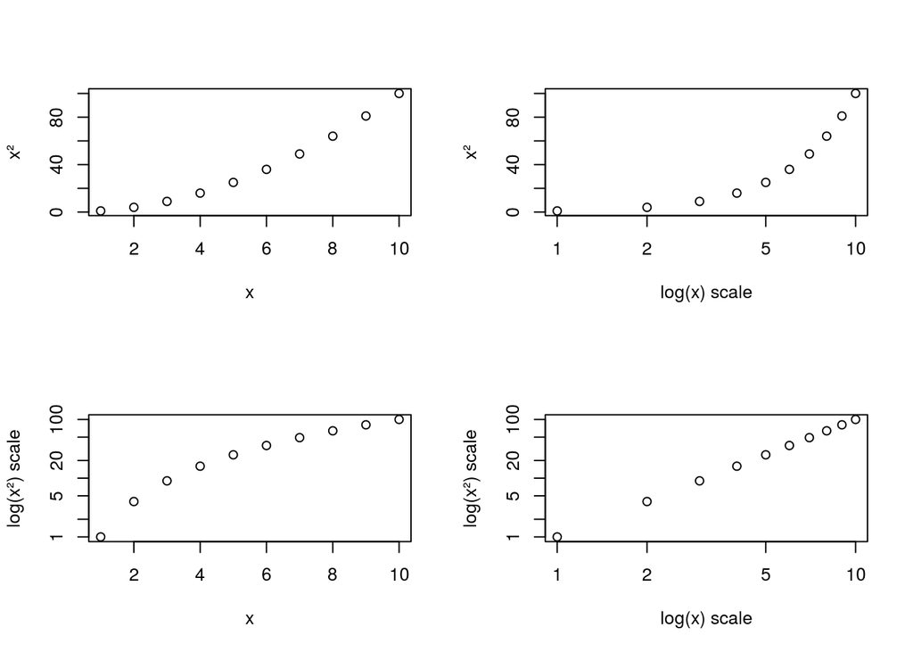

```r
par(mfrow=c(2,2))
plot(x = x<-1:10, y= y<-Power3(x,2), xlab="x", ylab="x²")
plot(x,y,log="x", xlab="log(x) scale", ylab="x²")
plot(x,y,log="y", xlab="x", ylab="log(x²) scale")
plot(x,y,log="xy", xlab="log(x) scale", ylab="log(x²) scale")
```

**(f) Create a function, `PlotPower()`, that allows you to create a plot of `x` against `x^a` for a fixed `a` and for a range of values of `x`. For instance, if you call**  
`> PlotPower(1:10,3)`  
**then a plot should be create with an x-axis taking on values 1,2,…,10, and a y-axis taking on values $1^3,2^3,...,10^3$.**

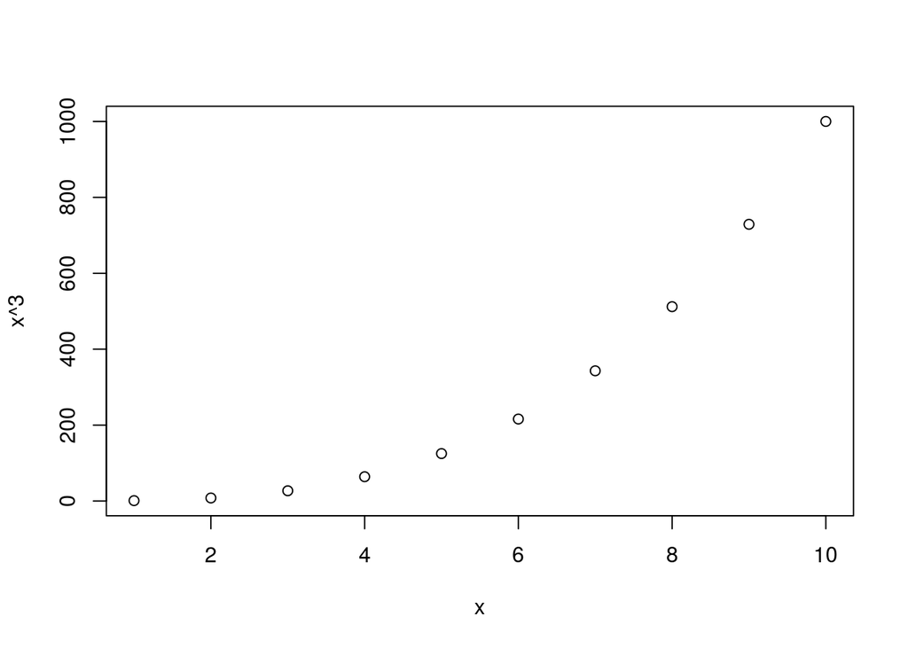

```r
par(mfrow=c(1,1))
PlotPower <- function(x,a){
  plot(x = x, y= y<-Power3(x,a), xlab="x", ylab=paste0("x^",a))
}

PlotPower(1:10,3)
```

**Q13. Using the `Boston` data set, fit classification models in order to predict whether a given suburb has a crime rate above or bellow the median. Explore logistic regression, LDA, and KNN models using various subsets of the predictors. Describe your findinds.**

```r
rm(list=ls())
data("Boston")

Boston$crim01 <- ifelse(Boston$crim > median(Boston$crim), "1", "0")
```

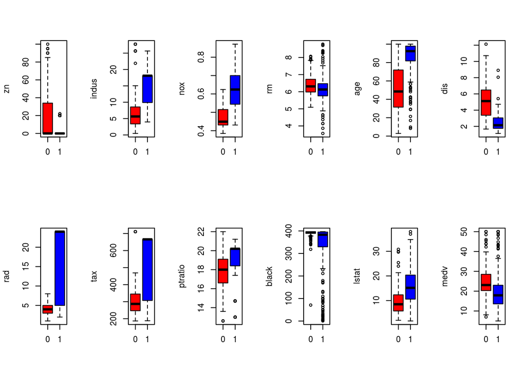

```r
attach(Boston)

par(mfrow=c(2,6))
for(i in names(Boston)){
  # excluding the own crime variables and the chas variable
  if( grepl(i, pattern="^crim|^chas")){ next}
  boxplot(eval(parse(text=i)) ~ crim01, ylab=i, col=c("red", "blue"), varwidth=T)
}
```

All variable shows trend to `crim01`, except`rm` which has some difference among the crimes situation but its most population lies in the same range values.

For `Chas` variable, i do a barplot, it is a dummy variable to if the tract bounds the river.

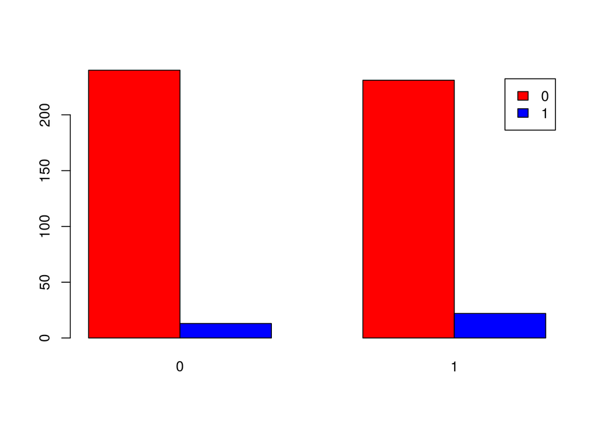

```r
par(mfrow=c(1,1))
aux <- table(chas, crim01)
barplot(aux, beside = T, legend=rownames(aux), col=c("red", "blue"))
```

The `chas` doesn’t show much difference for crime situation.

Selecting the relevant variables, i use the: `zn`, `indus`, `nox`, `age`, `dis`, `rad`, `tax`, `ptratio`, `black`, `lstat` and `medv`.

```r
set.seed(1)
vars = c("zn", "indus", "nox", "age", "dis", "rad", "tax", "ptratio", "black", "lstat", "medv", "crim01")
rows = sample(x=nrow(Boston), size=.75*nrow(Boston))
trainset = Boston[rows, vars]
testset = Boston[-rows, vars]
```

Modelling

```r
# LOGISTIC REGRESSION
lr.fit <- glm(as.factor(crim01) ~ ., data=trainset, family="binomial")
lr.probs <- predict(lr.fit, testset, type="response")
lr.pred <- ifelse(lr.probs>.5, "1","0")

test.err.lr <- mean(lr.pred!=testset$crim01)

# LINEAR DISCRIMINANT ANALYSIS
lda.fit <- lda(crim01 ~ ., data=trainset)
lda.pred <- predict(lda.fit, testset)
test.err.lda <- mean(lda.pred$class!=testset$crim01)

# QUADRATIC DISCRIMINANT ANALYSIS
qda.fit <- qda(crim01 ~ ., data=trainset)
qda.pred <- predict(qda.fit, testset)
test.err.qda <- mean(qda.pred$class!=testset$crim01)

# KNN-1
knn.pred <- knn(train=trainset, test=testset, cl=trainset$crim01, k=1)
test.err.knn_1 <- mean(knn.pred!=testset$crim01)

# KNN-CV
err.knn_cv <- rep(NA,9)
for(i in 2:10){
  knn.pred <- knn(train=trainset, test=testset, cl=trainset$crim01, k=i)
  err.knn_cv[i-1] <- mean(knn.pred!=testset$crim01)
}
test.err_knn_CV <- min(err.knn_cv)

round1 = data.frame("method"=c("LR", "LDA", "QDA", "KNN-1", "KNN-CV"), test.err=c(test.err.lr, test.err.lda, test.err.qda, test.err.knn_1, test.err_knn_CV))
round1
```

```
##   method   test.err
## 1     LR 0.08661417
## 2    LDA 0.14173228
## 3    QDA 0.13385827
## 4  KNN-1 0.08661417
## 5 KNN-CV 0.07874016
```

```r
coefs <- summary(lr.fit)$coefficients
coefs[order(coefs[,"Pr(>|z|)"], decreasing=F),]
```

```
##                  Estimate  Std. Error    z value     Pr(>|z|)
## nox          46.268552442 8.367479623  5.5295686 3.210193e-08
## (Intercept) -34.234056447 7.272602370 -4.7072636 2.510642e-06
## rad           0.605101758 0.171668295  3.5248312 4.237528e-04
## age           0.040524724 0.012981423  3.1217475 1.797811e-03
## dis           0.720872986 0.253963152  2.8384944 4.532691e-03
## zn           -0.083465982 0.037217704 -2.2426419 2.491992e-02
## tax          -0.007250196 0.003264131 -2.2211721 2.633931e-02
## medv          0.096672482 0.048899905  1.9769462 4.804771e-02
## ptratio       0.216821863 0.128042186  1.6933627 9.038645e-02
## indus        -0.064414786 0.051403490 -1.2531209 2.101617e-01
## black        -0.006369013 0.005175739 -1.2305513 2.184907e-01
## lstat        -0.001571527 0.056064484 -0.0280307 9.776377e-01
```

```r
vars <- c("nox", "rad", "ptratio", "black", "medv", "dis", "crim01")
trainset = Boston[rows, vars]
testset = Boston[-rows, vars]
```

Modelling

```r
# LOGISTIC REGRESSION
lr.fit <- glm(as.factor(crim01) ~ ., data=trainset, family="binomial")
lr.probs <- predict(lr.fit, testset, type="response")
lr.pred <- ifelse(lr.probs>.5, "1","0")

test.err.lr <- mean(lr.pred!=testset$crim01)

# LINEAR DISCRIMINANT ANALYSIS
lda.fit <- lda(crim01 ~ ., data=trainset)
lda.pred <- predict(lda.fit, testset)
test.err.lda <- mean(lda.pred$class!=testset$crim01)

# QUADRATIC DISCRIMINANT ANALYSIS
qda.fit <- qda(crim01 ~ ., data=trainset)
qda.pred <- predict(qda.fit, testset)
test.err.qda <- mean(qda.pred$class!=testset$crim01)

# KNN-1
knn.pred <- knn(train=trainset, test=testset, cl=trainset$crim01, k=1)
test.err.knn_1 <- mean(knn.pred!=testset$crim01)

# KNN-CV
err.knn_cv <- rep(NA,9)
for(i in 2:10){
  knn.pred <- knn(train=trainset, test=testset, cl=trainset$crim01, k=i)
  err.knn_cv[i-1] <- mean(knn.pred!=testset$crim01)
}
test.err_knn_CV <- min(err.knn_cv)

round2 = data.frame("method"=c("LR", "LDA", "QDA", "KNN-1", "KNN-CV"), test.err=c(test.err.lr, test.err.lda, test.err.qda, test.err.knn_1, test.err_knn_CV))
round2
```

```
##   method   test.err
## 1     LR 0.07874016
## 2    LDA 0.13385827
## 3    QDA 0.15748031
## 4  KNN-1 0.08661417
## 5 KNN-CV 0.10236220
```

Now, i try again, using the most 6 variable that seemed, in my observation from the graphs shown before, more associated with crime index. They are `zn`, `indus`, `nox`, `dis`, `rad` and `tax`.

```r
vars <- c("zn","indus", "nox", "dis", "rad", "tax", "crim01")
trainset = Boston[rows, vars]
testset = Boston[-rows, vars]
```

Modelling

```r
# LOGISTIC REGRESSION
lr.fit <- glm(as.factor(crim01) ~ ., data=trainset, family="binomial")
lr.probs <- predict(lr.fit, testset, type="response")
lr.pred <- ifelse(lr.probs>.5, "1","0")

test.err.lr <- mean(lr.pred!=testset$crim01)

# LINEAR DISCRIMINANT ANALYSIS
lda.fit <- lda(crim01 ~ ., data=trainset)
lda.pred <- predict(lda.fit, testset)
test.err.lda <- mean(lda.pred$class!=testset$crim01)

# QUADRATIC DISCRIMINANT ANALYSIS
qda.fit <- qda(crim01 ~ ., data=trainset)
qda.pred <- predict(qda.fit, testset)
test.err.qda <- mean(qda.pred$class!=testset$crim01)

# KNN-1
knn.pred <- knn(train=trainset, test=testset, cl=trainset$crim01, k=1)
test.err.knn_1 <- mean(knn.pred!=testset$crim01)

# KNN-CV
err.knn_cv <- rep(NA,9)
for(i in 2:10){
  knn.pred <- knn(train=trainset, test=testset, cl=trainset$crim01, k=i)
  err.knn_cv[i-1] <- mean(knn.pred!=testset$crim01)
}
test.err_knn_CV <- min(err.knn_cv)

round3 = data.frame("method"=c("LR", "LDA", "QDA", "KNN-1", "KNN-CV"), test.err=c(test.err.lr, test.err.lda, test.err.qda, test.err.knn_1, test.err_knn_CV))
round3
```

```
##   method   test.err
## 1     LR 0.09448819
## 2    LDA 0.14960630
## 3    QDA 0.08661417
## 4  KNN-1 0.00000000
## 5 KNN-CV 0.04724409
```

When i eliminate some variables, it helped for the non-linear approachs did better models. Seeing the three rounds on the graph bellow.

```r
performances <- rbind(cbind(round="round_1", round1), cbind(round="round_2", round2), cbind(round="round_3", round3))

library(reshape2)
dcast(data=performances, method ~ round, value.var="test.err")
```

```
##   method    round_1    round_2    round_3
## 1  KNN-1 0.08661417 0.08661417 0.00000000
## 2 KNN-CV 0.07874016 0.10236220 0.04724409
## 3    LDA 0.14173228 0.13385827 0.14960630
## 4     LR 0.08661417 0.07874016 0.09448819
## 5    QDA 0.13385827 0.15748031 0.08661417
```

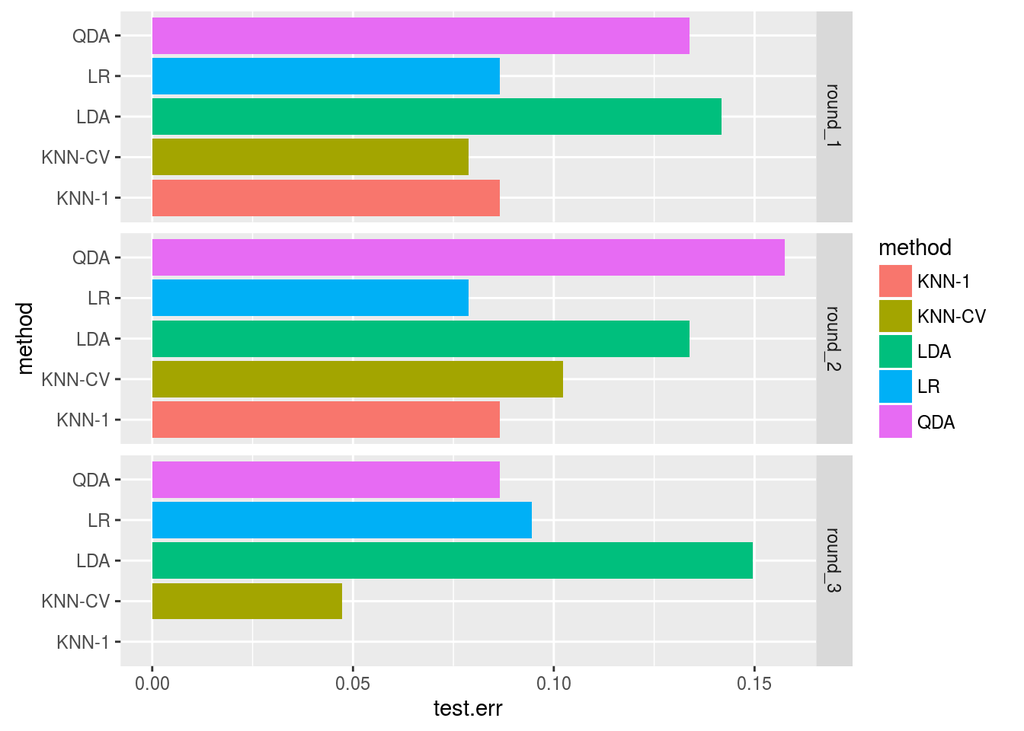

```r
library(ggplot2)
ggplot(data=performances, aes(x=method,y=test.err)) + geom_bar(stat="identity", aes(fill=method)) + coord_flip() + facet_grid(round ~ .)
```